# Airplane Customer Satisfaction

2023-04-07

Our Research Question:

What aspects should the airline market to convince business travelers to upgrade from economy to business class? (Marketing-focused)

Rational:

Increase profit for the airline. Business class was built to satisfy the need of business travelers. Business travelers make up to 75% of the annual airline profit because they are flying business or first class. On average the price of a business class ticket is four times the price of an economy ticket.

Applied methods to answer our RQ:

Which satisfaction variables do business class passengers rate significantly higher than economy class passengers? Select those with at least medium effect sizes. These are the aspects that should be marketed.

Load all necessary packages

Read in the data

```
##        id         satisfaction_v2       Gender          Customer.Type
##  Min.   :     1   Length:129880      Length:129880      Length:129880
##  1st Qu.: 32471   Class :character   Class :character   Class :character
##  Median : 64940   Mode  :character   Mode  :character   Mode  :character
##  Mean   : 64940
##  3rd Qu.: 97410
##  Max.   :129880
##
##       Age        Type.of.Travel        Class           Flight.Distance
##  Min.   : 7.00   Length:129880      Length:129880      Min.   :  31
##  1st Qu.:27.00   Class :character   Class :character   1st Qu.: 414
##  Median :40.00   Mode  :character   Mode  :character   Median : 844
##  Mean   :39.43                                         Mean   :1190
##  3rd Qu.:51.00                                         3rd Qu.:1744
##  Max.   :85.00                                         Max.   :4983
##
##  Inflight.wifi.service Departure.Arrival.time.convenient Ease.of.Online.booking
##  Min.   :0.000         Min.   :0.000                     Min.   :0.000
##  1st Qu.:2.000         1st Qu.:2.000                     1st Qu.:2.000
##  Median :3.000         Median :3.000                     Median :3.000
##  Mean   :2.729         Mean   :3.058                     Mean   :2.757
##  3rd Qu.:4.000         3rd Qu.:4.000                     3rd Qu.:4.000
##  Max.   :5.000         Max.   :5.000                     Max.   :5.000
##
##  Gate.location   Food.and.drink  Online.boarding  Seat.comfort
##  Min.   :0.000   Min.   :0.000   Min.   :0.000   Min.   :0.000
##  1st Qu.:2.000   1st Qu.:2.000   1st Qu.:2.000   1st Qu.:2.000
##  Median :3.000   Median :3.000   Median :3.000   Median :4.000
##  Mean   :2.977   Mean   :3.205   Mean   :3.253   Mean   :3.441
##  3rd Qu.:4.000   3rd Qu.:4.000   3rd Qu.:4.000   3rd Qu.:5.000
##  Max.   :5.000   Max.   :5.000   Max.   :5.000   Max.   :5.000
##
##  Inflight.entertainment On.board.service Leg.room.service Baggage.handling
##  Min.   :0.000          Min.   :0.000    Min.   :0.000    Min.   :1.000
##  1st Qu.:2.000          1st Qu.:2.000    1st Qu.:2.000    1st Qu.:3.000
##  Median :4.000          Median :4.000    Median :4.000    Median :4.000
##  Mean   :3.358          Mean   :3.383    Mean   :3.351    Mean   :3.632
##  3rd Qu.:4.000          3rd Qu.:4.000    3rd Qu.:4.000    3rd Qu.:5.000
##  Max.   :5.000          Max.   :5.000    Max.   :5.000    Max.   :5.000
##
##  Checkin.service Inflight.service  Cleanliness    Departure.Delay.in.Minutes
##  Min.   :0.000   Min.   :0.000    Min.   :0.000   Min.   :   0.00
##  1st Qu.:3.000   1st Qu.:3.000    1st Qu.:2.000   1st Qu.:   0.00
##  Median :3.000   Median :4.000    Median :3.000   Median :   0.00
##  Mean   :3.306   Mean   :3.642    Mean   :3.286   Mean   :  14.71
##  3rd Qu.:4.000   3rd Qu.:5.000    3rd Qu.:4.000   3rd Qu.:  12.00
##  Max.   :5.000   Max.   :5.000    Max.   :5.000   Max.   :1592.00
##
##  Arrival.Delay.in.Minutes
##  Min.   :   0.00
##  1st Qu.:   0.00
##  Median :   0.00
##  Mean   :  15.09
##  3rd Qu.:  13.00
##  Max.   :1584.00
##  NA's   :393
```

Clean the data: Remove all unnecessary columns and select only passengers that travel for business reasons. Remove class ‘Eco Plus’ so that we only have Eco and Business Class left.

```r
data_clean <- data %>%
  select(-c (id,Customer.Type,satisfaction_v2,Departure.Delay.in.Minutes,Arrival.Delay.in.Minutes))

data_clean <- data_clean %>%
  filter(Type.of.Travel == 'Business travel' & Class != 'Eco Plus')

data_clean[data_clean == 0] <- NA
view(data_clean)

#Class as factor + levels
data_clean$Class <- factor(data_clean$Class)

class_levels <- levels(data_clean$Class)
```

VISUALIZATION 1

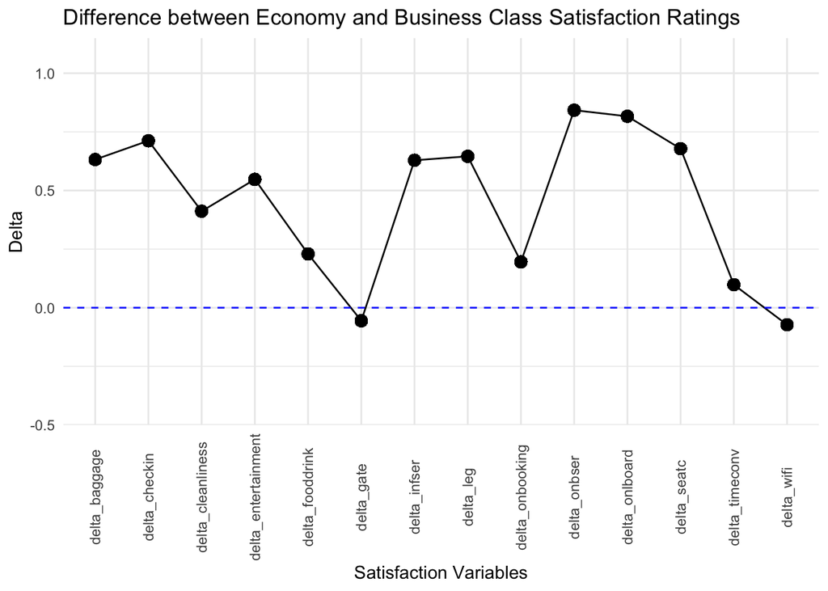

```r
# Create mean differences  as columns for each variable
  data_clean$Class <- factor(data_clean$Class)
data_clean <- as_tibble(data_clean)


data_clean <- data_clean %>%
  mutate_at(vars(Seat.comfort, Online.boarding, On.board.service, Baggage.handling, Checkin.service, Inflight.service, Inflight.wifi.service, Departure.Arrival.time.convenient, Ease.of.Online.booking, Gate.location, Food.and.drink, Inflight.entertainment, Leg.room.service, Cleanliness), as.numeric)


data_clean <- data_clean %>%
  filter(!is.na(Seat.comfort)) %>%
  filter(!is.na(Online.boarding))  %>%
  filter(!is.na(On.board.service)) %>%
  filter(!is.na(Baggage.handling))  %>%
  filter(!is.na(Checkin.service)) %>%
  filter(!is.na(Inflight.service))  %>%
  filter(!is.na(Inflight.wifi.service)) %>%
  filter(!is.na(Departure.Arrival.time.convenient))  %>%
  filter(!is.na(Ease.of.Online.booking))  %>%
  filter(!is.na(Gate.location)) %>%
  filter(!is.na(Food.and.drink))  %>%
  filter(!is.na(Inflight.entertainment)) %>%
  filter(!is.na(Cleanliness))  %>%
  filter(!is.na(Leg.room.service))


data_clean <- data_clean %>%
   mutate(delta_seatc = mean(Seat.comfort[Class == "Business"]) - mean(Seat.comfort[Class == "Eco"]),
         delta_onlboard = mean(Online.boarding[Class == "Business"]) - mean(Online.boarding[Class == "Eco"]),
         delta_onbser = mean(On.board.service[Class == "Business"]) - mean(On.board.service[Class == "Eco"]),
         delta_baggage = mean(Baggage.handling[Class == "Business"]) - mean(Baggage.handling[Class == "Eco"]),
         delta_checkin = mean(Checkin.service[Class == "Business"]) - mean(Checkin.service[Class == "Eco"]),
         delta_infser = mean(Inflight.service[Class == "Business"]) - mean(Inflight.service[Class == "Eco"]),
         delta_wifi = mean(Inflight.wifi.service[Class == "Business"]) - mean(Inflight.wifi.service[Class == "Eco"]),
         delta_timeconv = mean(Departure.Arrival.time.convenient[Class == "Business"]) - mean(Departure.Arrival.time.convenient[Class == "Eco"]),
          delta_onbooking = mean(Ease.of.Online.booking[Class == "Business"]) - mean(Ease.of.Online.booking[Class == "Eco"]),
         delta_gate = mean(Gate.location[Class == "Business"])- mean(Gate.location [Class == "Eco"]),
         delta_fooddrink = mean(Food.and.drink[Class == "Business"]) - mean(Food.and.drink[Class == "Eco"]),
         delta_entertainment = mean(Inflight.entertainment[Class == "Business"]) - mean(Inflight.entertainment[Class == "Eco"]),
         delta_leg = mean(Leg.room.service[Class == "Business"]) - mean(Leg.room.service[Class == "Eco"]),
         delta_cleanliness = mean(Cleanliness[Class == "Business"]) - mean(Cleanliness[Class == "Eco"]))

# Create Visualization


library(ggplot2)

# Select the columns that you want to use in the plot
df_plot <- data_clean %>%
  select(starts_with("delta_"))

# Reshape the data into long format
df_plot_long <- tidyr::gather(df_plot, key = "variable", value = "delta")

# Create the plot
ggplot(df_plot_long, aes(x = variable, y = delta))  +
  geom_point(size = 3) +
  geom_line(group = 1) +
  scale_y_continuous(expand = expansion(mult = c(0, 0.1))) +
  geom_hline(yintercept = 0, linetype = "dashed", color = "blue") +
  labs(title = "Difference between Economy and Business Class Satisfaction Ratings",x = "Satisfaction Variables", y = "Delta") +
  coord_cartesian(ylim = c(-0.5, 1)) +
   theme_minimal() +
  theme(axis.text.x = element_text(angle = 90, vjust = 0.5))
```

VISUALIZATION 2 –> bit confusing haha

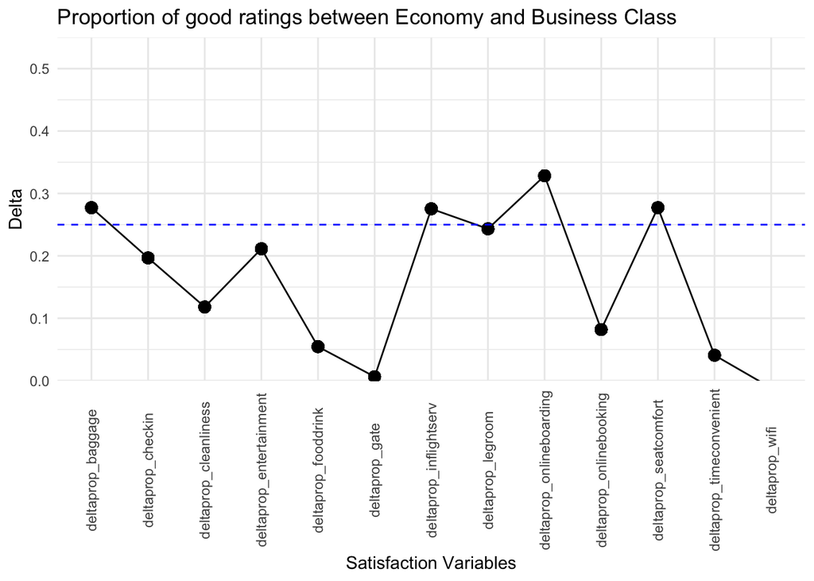

```r
data_clean <- data_clean %>%
  mutate(proportion_seatcomfort_business = sum(Seat.comfort > 3 & Class == "Business") / sum(Class == "Business"),
         proportion_seatcomfort_economy = sum(Seat.comfort > 3 & Class == "Eco") / sum(Class == "Eco"),
         proportion_onlineboarding_business = sum(Online.boarding > 3 & Class == "Business") / sum(Class == "Business"),
         proportion_onlineboarding_economy = sum(Online.boarding > 3 & Class == "Eco") / sum(Class == "Eco"),
         proportion_onboardserv_business = sum(On.board.service > 3 & Class == "Business") / sum(Class == "Business"),
         proportion_onboardserv_economy = sum(On.board.service> 3 & Class == "Eco") / sum(Class == "Eco"),
         proportion_baggage_business = sum(Baggage.handling > 3 & Class == "Business") / sum(Class == "Business"),
         proportion_baggage_economy = sum(Baggage.handling > 3 & Class == "Eco") / sum(Class == "Eco"),
         proportion_checkin_business = sum(Checkin.service > 3 & Class == "Business") / sum(Class == "Business"),
         proportion_checkin_economy = sum(Checkin.service > 3 & Class == "Eco") / sum(Class == "Eco"),
         proportion_inflightserv_business = sum(Inflight.service > 3 & Class == "Business") / sum(Class == "Business"),
         proportion_inflightserv_economy = sum(Inflight.service > 3 & Class == "Eco") / sum(Class == "Eco"),
         proportion_wifi_business = sum(Inflight.wifi.service > 3 & Class == "Business") / sum(Class == "Business"),
         proportion_wifi_economy = sum(Inflight.wifi.service > 3 & Class == "Eco") / sum(Class == "Eco"),
         proportion_timeconvenient_business = sum(Departure.Arrival.time.convenient > 3 & Class == "Business") / sum(Class == "Business"),
         proportion_timeconvenient_economy = sum(Departure.Arrival.time.convenient > 3 & Class == "Eco") / sum(Class == "Eco"),
        proportion_onlinebooking_business = sum(Ease.of.Online.booking > 3 & Class == "Business") / sum(Class == "Business"),
         proportion_onlinebooking_economy = sum(Ease.of.Online.booking > 3 & Class == "Eco") / sum(Class == "Eco"),
         proportion_gate_business = sum(Gate.location > 3 & Class == "Business") / sum(Class == "Business"),
         proportion_gate_economy = sum(Gate.location > 3 & Class == "Eco") / sum(Class == "Eco"),
         proportion_fooddrink_business = sum(Food.and.drink> 3 & Class == "Business") / sum(Class == "Business"),
         proportion_fooddrink_economy = sum(Food.and.drink > 3 & Class == "Eco") / sum(Class == "Eco"),
         proportion_entertainment_business = sum(Inflight.entertainment > 3 & Class == "Business") / sum(Class == "Business"),
         proportion_entertainment_economy = sum(Inflight.entertainment > 3 & Class == "Eco") / sum(Class == "Eco"),
        proportion_cleanliness_business = sum(Cleanliness > 3 & Class == "Business") / sum(Class == "Business"),
         proportion_cleanliness_economy = sum(Cleanliness > 3 & Class == "Eco") / sum(Class == "Eco"),
         proportion_legroom_business = sum(Leg.room.service> 3 & Class == "Business") / sum(Class == "Business"),
         proportion_legroom_economy = sum(Leg.room.service > 3 & Class == "Eco") / sum(Class == "Eco"),
          deltaprop_seatcomfort = proportion_seatcomfort_business - proportion_seatcomfort_economy,
          deltaprop_onlineboarding = proportion_onlineboarding_business - proportion_onlineboarding_economy,
          deltaprop_seatcomfort = proportion_baggage_business - proportion_baggage_economy,
          deltaprop_baggage = proportion_baggage_business - proportion_baggage_economy,
          deltaprop_checkin = proportion_checkin_business - proportion_checkin_economy,
          deltaprop_inflightserv = proportion_inflightserv_business - proportion_inflightserv_economy,
          deltaprop_wifi = proportion_wifi_business - proportion_wifi_economy,
          deltaprop_timeconvenient = proportion_timeconvenient_business - proportion_timeconvenient_economy,
          deltaprop_onlinebooking = proportion_onlinebooking_business - proportion_onlinebooking_economy,
          deltaprop_gate = proportion_gate_business - proportion_gate_economy,
          deltaprop_fooddrink = proportion_fooddrink_business - proportion_fooddrink_economy,
          deltaprop_entertainment = proportion_entertainment_business - proportion_entertainment_economy,
          deltaprop_cleanliness = proportion_cleanliness_business - proportion_cleanliness_economy,
          deltaprop_legroom = proportion_legroom_business - proportion_legroom_economy)


df_plot_prop <- data_clean %>%
  select(starts_with("deltaprop_"))

# Reshape the data into long format
df_plot_prop_long <- tidyr::gather(df_plot_prop, key = "variable", value = "proportion")

# Create the plot
ggplot(df_plot_prop_long, aes(x = variable, y = proportion))  +
  geom_point(size = 3) +
  geom_line(group = 1) +
  scale_y_continuous(expand = expansion(mult = c(0, 0.1))) +
  geom_hline(yintercept = 0.25, linetype = "dashed", color = "blue") +
  labs(title = "Proportion of good ratings between Economy and Business Class ",x = "Satisfaction Variables", y = "Delta") +
  coord_cartesian(ylim = c(0, 0.5)) +
   theme_minimal() +
  theme(axis.text.x = element_text(angle = 90, vjust = 0.5))
```